# Exploratory Data Analysis gives us an insight into the data. It can showcase a story of the data and hence is a vital part of machine learning.

#### Analysis of Home Ownership with Interest Rate

Next we evaluated if home ownership had a relation with interest rate. As per the graph we observe that the interest rate was the highest for borrowers who had their homes on rent whoch is predictable considering that they do not have a property of their own hence, interest rate is higher

```
  home_ownership       mean
1            1.0  12.925648
0            0.0  13.605962
```

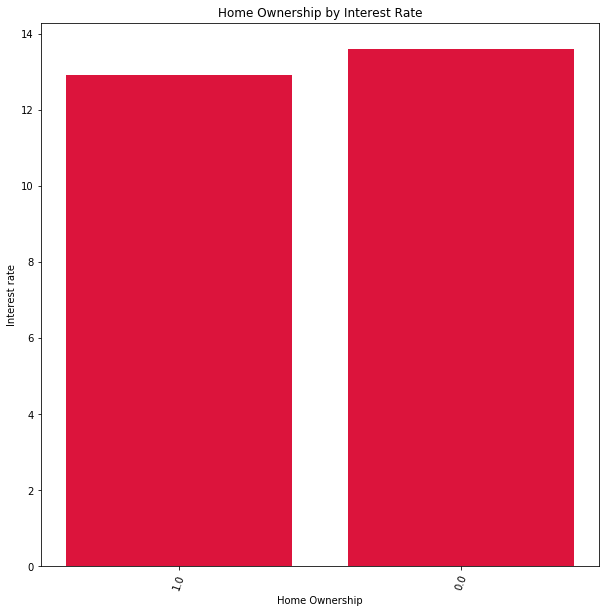

```python
load_data['home_ownership'] = load_data['home_ownership'].astype(str)
curbal_trend=load_data[['home_ownership','int_rate']].groupby(['home_ownership'])['int_rate'].mean().reset_index(name='mean').sort_values(['mean'],ascending=True)
print(curbal_trend)

x = np.array(range(len(curbal_trend)))
y = curbal_trend['mean']
my_xticks = curbal_trend['home_ownership']
#plt.xticks(count_code.index, count_code['code'], rotation=90,y='count')
plt.xticks(x, my_xticks)
#plt.plot(x,y)
plt.xticks(rotation=70)
plt.bar(x,y,color='crimson')
plt.title('Home Ownership by Interest Rate')
plt.ylabel('Interest rate')
plt.xlabel('Home Ownership')
# plt.savefig(os.path.join('Part1','TimeSeries.png'),dpi=100)
#droppingcolumn fintime
plt.show()
plt.clf()
```

## Exploratory Data Analysis of Rejected Loan Data Set

```python
declined_load_data=pd.read_csv("CleanedDeclineddata.csv",encoding = "ISO-8859-1")
```

### Analysis of Risk Score and Employment Length

As per the rejected loan data set the mean risk score is the highest for a borrower who has a an employment lenght of 7 years. Hence there are other factors involved in rejecting a loan apart from risk score.

```
    emp_length        mean
5            5   66.634905
0            0  143.311708
1            1  328.155862
2            2  372.415967
3            3  387.153664
4            4  397.613084
8            8  430.117794
9            9  441.864611
6            6  444.303975
10          10  451.632849
7            7  460.729007
```

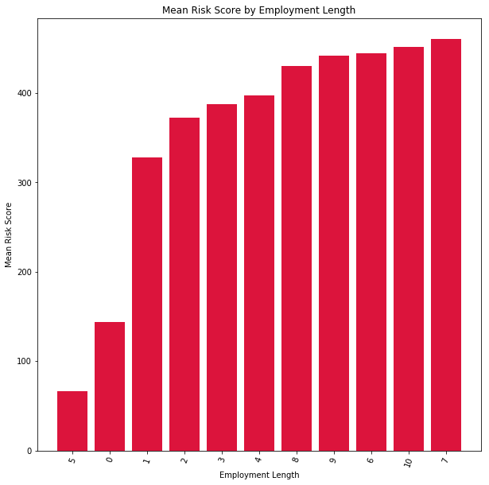

```python
# load_data['home_ownership'] = load_data['home_ownership'].astype(str)
emplen_trend=declined_load_data[['emp_length','Risk_Score']].groupby(['emp_length'])['Risk_Score'].mean().reset_index(name='mean').sort_values(['mean'],ascending=True)
print(emplen_trend)

x = np.array(range(len(emplen_trend)))
y = emplen_trend['mean']
my_xticks = emplen_trend['emp_length']
#plt.xticks(count_code.index, count_code['code'], rotation=90,y='count')
plt.xticks(x, my_xticks)
#plt.plot(x,y)
plt.xticks(rotation=70)
plt.bar(x,y,color='crimson')
plt.title('Mean Risk Score by Employment Length')
plt.ylabel('Mean Risk Score')
plt.xlabel('Employment Length')
# plt.savefig(os.path.join('Part1','TimeSeries.png'),dpi=100)
#droppingcolumn fintime
plt.show()
plt.clf()
```

## Analysis of Approval of Loans

Next we analyse Approval by various features. The loans that have been approved have Approval=1 and loans that are not approved have Approval=0. We first combine the data of Approved and Rejected Loans. First we established all the columns common to both data sets.

```python
declined_load_data.columns
```

```
Index(['amount_requested', 'Risk_Score', 'dti', 'State', 'emp_length',
       'policy_code', 'timestamp', 'app_month', 'app_year'],
      dtype='object')
```

Identified the common columns in the declined loan dataset

```python
import numpy as np
### Since issue year in accepted loans is equivalent to application date
declined_cols=pd.DataFrame()
declined_load_data['issue_year']=declined_load_data['app_year']
# declined_col_list=declined_load_data['amount_requested','Risk_Score', 'dti','State', 'emp_length','issue_year']
# declined_cols = pd.DataFrame(np.array(declined_col_list))
declined_cols=declined_load_data[['amount_requested','Risk_Score','dti','State', 'emp_length','issue_year']]
declined_cols['Approval']=0
declined_cols.head()
```

|  | amount_requested | Risk_Score | dti | State | emp_length | issue_year | Approval |
| --- | --- | --- | --- | --- | --- | --- | --- |
| 0 | 1000.0 | 693.0 | 10.00 | 33 | 4 | 2007 | 0 |
| 1 | 1000.0 | 703.0 | 10.00 | 19 | 1 | 2007 | 0 |
| 2 | 11000.0 | 715.0 | 10.00 | 20 | 1 | 2007 | 0 |
| 3 | 6000.0 | 698.0 | 38.64 | 19 | 1 | 2007 | 0 |
| 4 | 1500.0 | 509.0 | 9.43 | 20 | 1 | 2007 | 0 |

```python
load_data.columns
```

```
Index(['loan_amnt', 'funded_amnt', 'funded_amnt_inv', 'term', 'int_rate',
       'installment', 'grade', 'emp_length', 'home_ownership', 'annual_inc',
       ...
       'total_bal_ex_mort', 'total_bc_limit', 'total_il_high_credit_limit',
       'hardship_flag', 'disbursement_method', 'debt_settlement_flag',
       'timestamp', 'issue_year', 'issue_month', 'Risk_Score'],
      dtype='object', length=109)
```

Identified the common columns in the accepted loan dataset

```python
accepted_cols=pd.DataFrame()
accepted_cols=load_data[['loan_amnt','Risk_Score','dti','addr_state', 'emp_length','issue_year']]
accepted_cols['Approval']=1
accepted_cols.columns=['amount_requested','Risk_Score','dti','State', 'emp_length','issue_year','Approval']
accepted_cols.head()
```

|  | amount_requested | Risk_Score | dti | State | emp_length | issue_year | Approval |
| --- | --- | --- | --- | --- | --- | --- | --- |
| 0 | 5000 | 737.0 | 27.65 | 4 | 10 | 2011 | 1 |
| 1 | 2500 | 742.0 | 1.00 | 11 | 1 | 2011 | 1 |
| 2 | 2400 | 737.0 | 8.72 | 15 | 10 | 2011 | 1 |
| 3 | 10000 | 692.0 | 20.00 | 5 | 10 | 2011 | 1 |
| 4 | 3000 | 697.0 | 17.94 | 38 | 1 | 2011 | 1 |

#### Concat both dataframes

```python
combine_loan_data=pd.DataFrame()
decline=declined_cols
accept=accepted_cols
combine_loan_data=pd.concat([decline,accept],axis=0)
combine_loan_data.to_csv("combineloandata.csv",index=False)
```

#### Analysis of Risk Score with Approval and Issue Year¶

```
    issue_year  Approval        mean
21        2017         1  702.296764
20        2017         0  342.914933
19        2016         1  697.378663
18        2016         0  135.230525
17        2015         1  695.649960
16        2015         0  113.743341
15        2014         1  694.497345
14        2014         0  549.520121
12        2013         0  591.493768
13        2013         1  696.998338
11        2012         1  703.387407
10        2012         0  597.619667
9         2011         1  716.991713
8         2011         0  571.325825
7         2010         1  715.041796
6         2010         0  541.403248
5         2009         1  716.965916
4         2009         0  515.131284
3         2008         1  699.101964
2         2008         0  516.201516
1         2007         1  691.966833
0         2007         0  539.419416
```

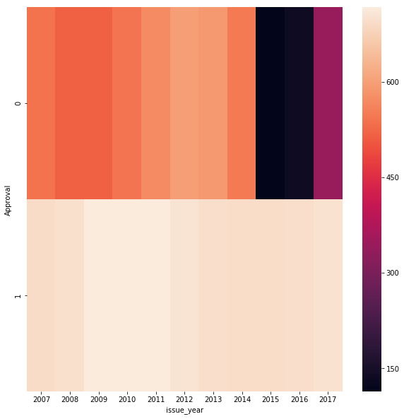

```python
approval_risk_trend=combine_loan_data[['issue_year','Risk_Score','Approval']].groupby(['issue_year','Approval'])['Risk_Score'].mean().reset_index(name='mean').sort_values(['issue_year'],ascending=False)
print(approval_risk_trend)
# g = sns.factorplot(x="issue_year", y="count", hue="Approval", data=approval_trend,size=7, kind="bar", palette="muted")
# g.despine(left=True)
# plt.show()
flights = approval_risk_trend.pivot("Approval","issue_year","mean")
ax = sns.heatmap(flights)
plt.show()



##Analysis of Average Interest Rate by Issue Year
##Mean Interest Rate was maximum in year 2013
```

#### Analysis of Approval Status with Issue Year

```python
# load_data['home_ownership'] = load_data['home_ownership'].astype(str)
approval_year_trend=combine_loan_data[['Approval','issue_year']].groupby(['issue_year','Approval'])['Approval'].count().reset_index(name='count').sort_values(['count'],ascending=False)
print(approval_year_trend)

# x = np.array(range(len(emplen_trend)))
# y = emplen_trend['mean']
# my_xticks = emplen_trend['emp_length']
# #plt.xticks(count_code.index, count_code['code'], rotation=90,y='count')
# plt.xticks(x, my_xticks)
# #plt.plot(x,y)
# plt.xticks(rotation=70)
# plt.bar(x,y,color='crimson')
# plt.title('Mean Risk Score by Employment Length')
# plt.ylabel('Mean Risk Score')
# plt.xlabel('Employment Length')
# # plt.savefig(os.path.join('Part1','TimeSeries.png'),dpi=100)
# #droppingcolumn fintime
# plt.show()
# plt.clf()
```

```
    issue_year  Approval    count
20        2017         0  7072557
18        2016         0  4769858
16        2015         0  2859375
14        2014         0  1933696
12        2013         0   760942
21        2017         1   443579
19        2016         1   434407
17        2015         1   421093
10        2012         0   337273
15        2014         1   235627
8         2011         0   217792
13        2013         1   134814
6         2010         0   112561
4         2009         0    56991
11        2012         1    53365
2         2008         0    25596
9         2011         1    21721
7         2010         1    12537
5         2009         1     5281
0         2007         0     5274
3         2008         1     2393
1         2007         1      603
```

#### Analysis of Count of Approvals and Rejects by Issue Year

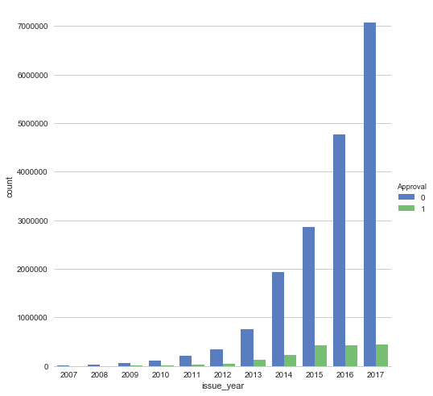

```python
import seaborn as sns
sns.set(style="whitegrid")
approval_trend=combine_loan_data[['Approval','issue_year']].groupby(['issue_year','Approval'])['Approval'].count().reset_index(name='count').sort_values(['Approval'],ascending=False)

g = sns.factorplot(x="issue_year", y="count", hue="Approval", data=approval_trend,size=7, kind="bar", palette="muted")
g.despine(left=True)
plt.show()
```

#### Analysis of Number of Approvals and Number of rejects

```
   Approval     count
0         0  18151915
1         1   1765420
```

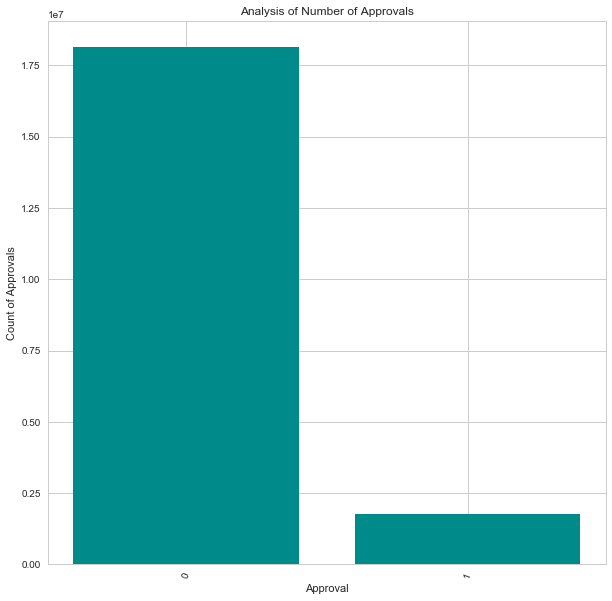

```python
approval_trend=combine_loan_data[['Approval']].groupby(['Approval'])['Approval'].count().reset_index(name='count').sort_values(['count'],ascending=False)
print(approval_trend)

x = np.array(range(len(approval_trend)))
y = approval_trend['count']
my_xticks = approval_trend['Approval']
#plt.xticks(count_code.index, count_code['code'], rotation=90,y='count')
plt.xticks(x, my_xticks)
#plt.plot(x,y)
plt.xticks(rotation=70)
plt.bar(x,y,color='darkcyan')
plt.title('Analysis of Number of Approvals')
plt.ylabel('Count of Approvals')
plt.xlabel('Approval')
# plt.savefig(os.path.join('Part1','TimeSeries.png'),dpi=100)
#droppingcolumn fintime
plt.show()
plt.clf()
```

#### Analysis of Risk Score with Approval

Mean Risk score was analysed for Loans that were accepted and rejected

```
   Approval        mean
1         1  698.395898
0         0  294.216643
```

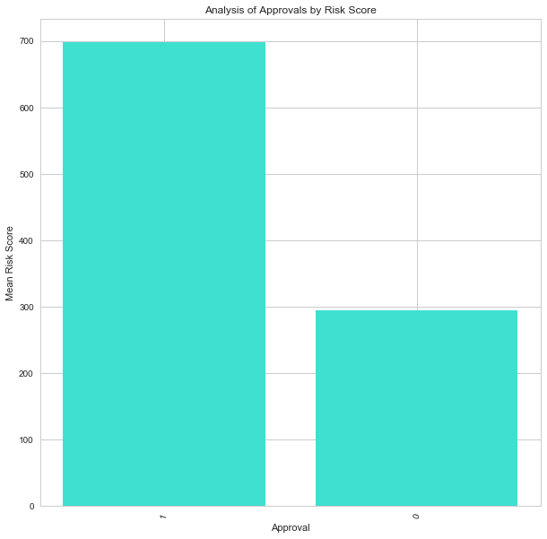

```python
approval_trend=combine_loan_data[['Approval','Risk_Score']].groupby(['Approval'])['Risk_Score'].mean().reset_index(name='mean').sort_values(['mean'],ascending=False)
print(approval_trend)

x = np.array(range(len(approval_trend)))
y = approval_trend['mean']
my_xticks = approval_trend['Approval']
#plt.xticks(count_code.index, count_code['code'], rotation=90,y='count')
plt.xticks(x, my_xticks)
#plt.plot(x,y)
plt.xticks(rotation=70)
plt.bar(x,y,color='turquoise')
plt.title('Analysis of Approvals by Risk Score')
plt.ylabel('Mean Risk Score')
plt.xlabel('Approval')
# plt.savefig(os.path.join('Part1','TimeSeries.png'),dpi=100)
#droppingcolumn fintime
plt.show()
plt.clf()
```

### Analysis of Employment Length by Mean Risk Score

We observe that the mean risk score is the highest for employment length 9 years followed by 10 years. Another noted observation is that the 0 employment years has higher mean score than employment length of 5 years

[output not shown]

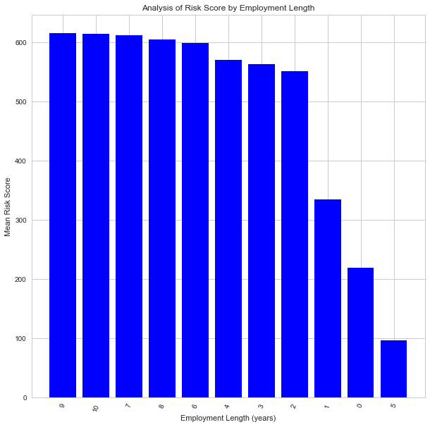

```python
emp_approval_trend=combine_loan_data[['emp_length','Risk_Score']].groupby(['emp_length'])['Risk_Score'].mean().reset_index(name='mean').sort_values(['mean'],ascending=False)
print(approval_trend)

x = np.array(range(len(emp_approval_trend)))
y = emp_approval_trend['mean']
my_xticks = emp_approval_trend['emp_length']
#plt.xticks(count_code.index, count_code['code'], rotation=90,y='count')
plt.xticks(x, my_xticks)
#plt.plot(x,y)
plt.xticks(rotation=70)
plt.bar(x,y,color='blue')
plt.title('Analysis of Risk Score by Employment Length')
plt.ylabel('Mean Risk Score')
plt.xlabel('Employment Length (years)')
# plt.savefig(os.path.join('Part1','TimeSeries.png'),dpi=100)
#droppingcolumn fintime
plt.show()
plt.clf()
```

#### Analysis of Risk Score with Approval and Issue Year

```
    issue_year  Approval        mean
21        2017         1  702.296764
20        2017         0  342.914933
19        2016         1  697.378663
18        2016         0  135.230525
17        2015         1  695.649960
16        2015         0  113.743341
15        2014         1  694.497345
14        2014         0  549.520121
12        2013         0  591.493768
13        2013         1  696.998338
11        2012         1  703.387407
10        2012         0  597.619667
9         2011         1  716.991713
8         2011         0  571.325825
7         2010         1  715.041796
6         2010         0  541.403248
5         2009         1  716.965916
4         2009         0  515.131284
3         2008         1  699.101964
2         2008         0  516.201516
1         2007         1  691.966833
0         2007         0  539.419416
```

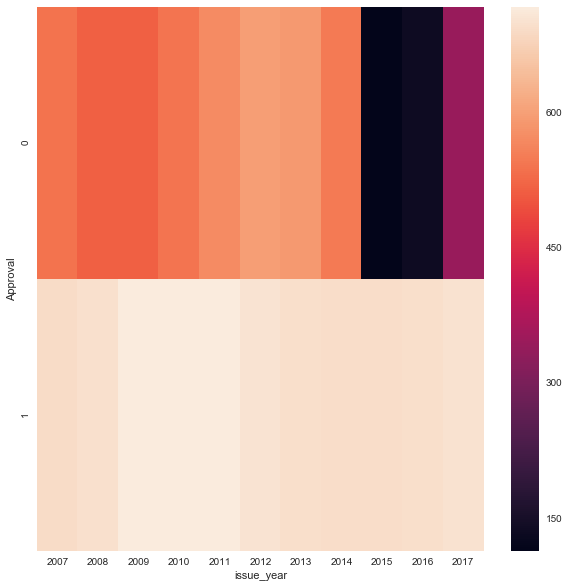

```python
approval_risk_trend=combine_loan_data[['issue_year','Risk_Score','Approval']].groupby(['issue_year','Approval'])['Risk_Score'].mean().reset_index(name='mean').sort_values(['issue_year'],ascending=False)
print(approval_risk_trend)
# g = sns.factorplot(x="issue_year", y="count", hue="Approval", data=approval_trend,size=7, kind="bar", palette="muted")
# g.despine(left=True)
# plt.show()
flights = approval_risk_trend.pivot("Approval","issue_year","mean")
ax = sns.heatmap(flights)
plt.show()



##Analysis of Average Interest Rate by Issue Year
##Mean Interest Rate was maximum in year 2013
```

#### Analysis of Mean Risk Score with emplyement length and Issue Year

We observe that the mean risk score is the highest for employment length 9 years followed by 10 years for years 2013 and 2014. Another noted observation is mean risk score is the highest for employment lenght 10 but is consistenty high for all employment years for the year 2012.

[output not shown]

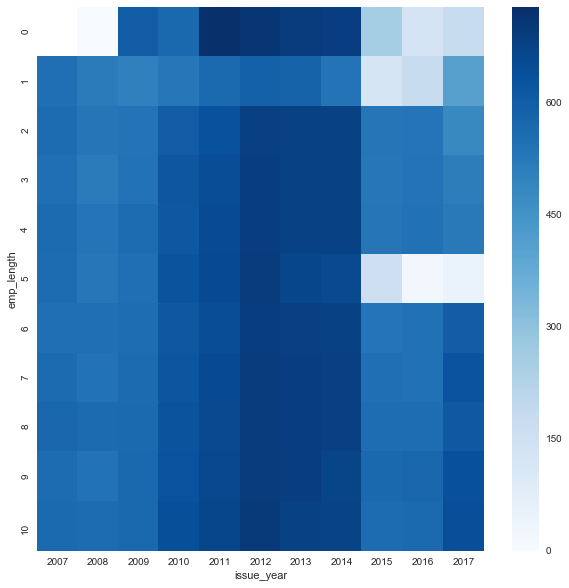

```python
emp_year_trend=combine_loan_data[['issue_year','Risk_Score','emp_length']].groupby(['issue_year','emp_length'])['Risk_Score'].mean().reset_index(name='mean').sort_values(['issue_year'],ascending=False)
print(approval_risk_trend)
# g = sns.factorplot(x="issue_year", y="count", hue="Approval", data=approval_trend,size=7, kind="bar", palette="muted")
# g.despine(left=True)
# plt.show()
flights = emp_year_trend.pivot("emp_length","issue_year","mean")
ax = sns.heatmap(flights,cmap="Blues")
plt.show()



##Analysis of Average Interest Rate by Issue Year
##Mean Interest Rate was maximum in year 2013
```

### Our explanatory data gave us a clear insight how the features are trending through out the dataset.

The text in the document by Tushar Goel & Trupti Gore is licensed under CC BY 3.0 https://creativecommons.org/licenses/by/3.0/us/

### MIT License

The code in the document by Tushar Goel & Trupti Gore is licensed under the MIT License https://opensource.org/licenses/MIT

Copyright (c) 2018 Trupti Gore

Permission is hereby granted, free of charge, to any person obtaining a copy of this software and associated documentation files (the "Software"), to deal in the Software without restriction, including without limitation the rights to use, copy, modify, merge, publish, distribute, sublicense, and/or sell copies of the Software, and to permit persons to whom the Software is furnished to do so, subject to the following conditions:

The above copyright notice and this permission notice shall be included in all copies or substantial portions of the Software.

THE SOFTWARE IS PROVIDED "AS IS", WITHOUT WARRANTY OF ANY KIND, EXPRESS OR IMPLIED, INCLUDING BUT NOT LIMITED TO THE WARRANTIES OF MERCHANTABILITY, FITNESS FOR A PARTICULAR PURPOSE AND NONINFRINGEMENT. IN NO EVENT SHALL THE AUTHORS OR COPYRIGHT HOLDERS BE LIABLE FOR ANY CLAIM, DAMAGES OR OTHER LIABILITY, WHETHER IN AN ACTION OF CONTRACT, TORT OR OTHERWISE, ARISING FROM, OUT OF OR IN CONNECTION WITH THE SOFTWARE OR THE USE OR OTHER DEALINGS IN THE SOFTWARE.